# Estimating PDF Parameters

Owain Morgan

24/02/2022

The problem at hand at first sight could be considered an easy one- namely how to fit the most appropriate distribution to a given set of data.

```r
library(tidyverse)
library(stats4)

library(kdensity)
load("data/stomach_dataset.Rdata")
library(dplyr)
library(tidyverse)
library(bbmle)
library(mizer)

## We here only have species, prey & predator weight and the number of prey
df <- stom_df |>
  transmute(Species = pred_species,
            wprey = prey_weight_g,
            wpredator = pred_weight_g,
            Nprey = prey_count / n_stomachs)

ogDF <- df


## Remove any observation with wprey = 0
df = df %>%
  filter(df$wprey != 0)


## Add ppmr and log ppmr columns for each observation

df = df %>%
  mutate(ppmr = wpredator/wprey, l = log(wpredator/wprey))


whitingDF <- filter(df, df$Species == "Merlangius merlangus")
```

## Quantifying Closeness

As we seek to find the most approprite fit for our data, it is first imperative that we can quantify what is a good fit. Consider these two Gamma estimates to the whiting stomach log predator-prey mass ratio.

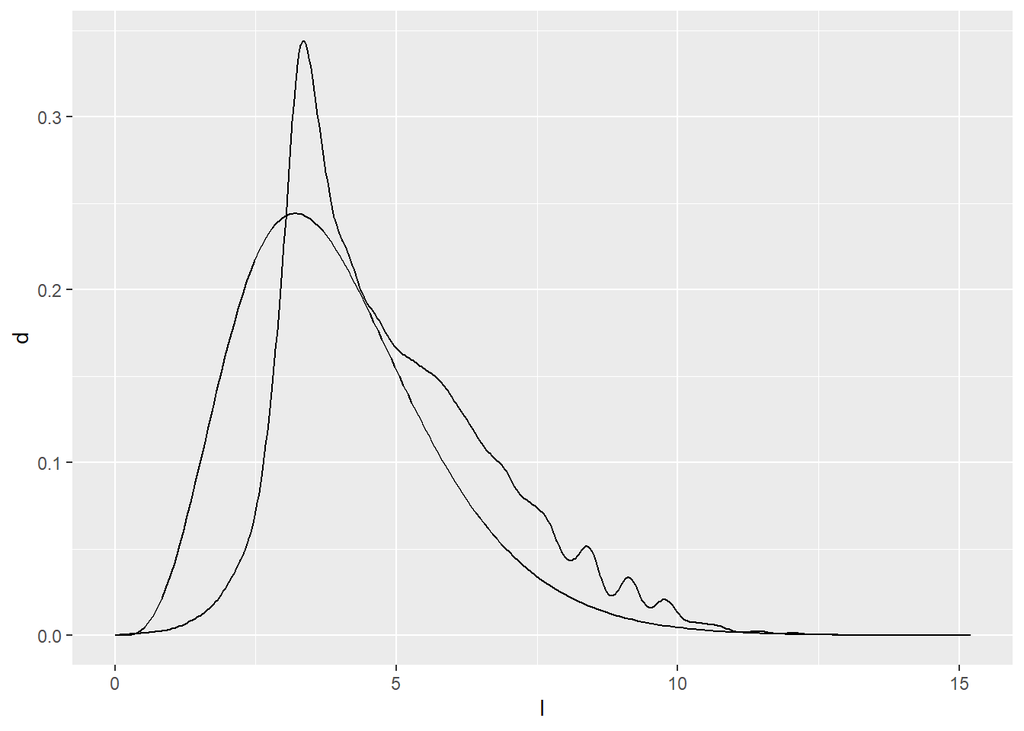

Using alpha = 5, beta = 0.8

```r
gammdf <- tibble(
  l = seq(0, 15, length.out=200),
  d = dgamma(l, shape = 5, scale=0.8)
)
ggplot(whitingDF, aes(x = l), adjust = 1.5) +
  geom_density() +
  geom_line(data = gammdf, aes(l, d))
```

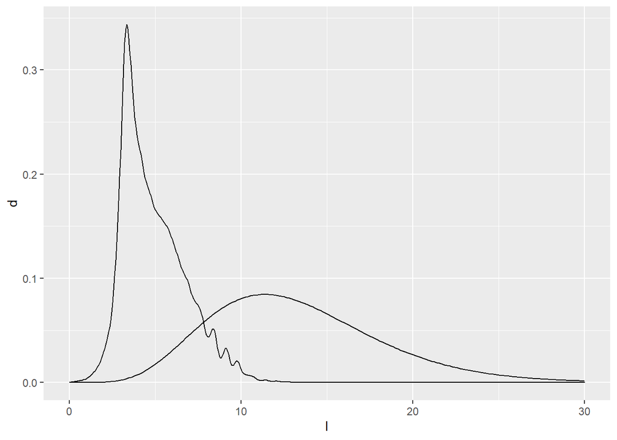

Using alpha = 7, beta = 1.9

```r
gammdf <- tibble(
  l = seq(0, 30, length.out=200),
  d = dgamma(l, shape = 7, scale=1.9)
)
ggplot(whitingDF, aes(x = l), adjust = 1.5) +
  geom_density() +
  geom_line(data = gammdf, aes(l, d)) +
  xlim(0,30)
```

Clearly, the first choice of parameters is far more appropriate for the data in question. Our first task is to consider some way of quantifying the difference.

Let the kernel density estimate for the data be $f_k(x)$ and let the pdf of our estimate be $f_E(x)$. Then we can estimate the error,
$$\varepsilon = \int_{- \infty}^{\infty} \left( f_k(x) - f_E(x) \right)^2 d x.$$

## Whiting Data

```r
whitingKDE <- kdensity(whitingDF$l)


gammaWhitingGap <- function(x , siap, maint)
{dgamma(x, shape = siap, scale = maint) - whitingKDE(x)}
gammaWhitingGapSquared <- function (x, siap, maint) {gammaWhitingGap(x, siap, maint)^2}

gammaErrorSq <- function (alpha, beta) {integrate(gammaWhitingGapSquared, lower = -1, upper = 30, siap = alpha, maint =beta)}

alphaNum <- 5
alphaTable <- seq(1, 10, length.out = alphaNum)
betaNum <- 5
betaTable <- seq(0.01, 10, length.out = betaNum)
gammaTable <- matrix(nrow = alphaNum, ncol = betaNum)
for (i in 1:alphaNum) {
  for (j in 1:betaNum) {
    gammaTable[i,j] = gammaErrorSq(alphaTable[i], betaTable[j])$value
  }
}

gammaTable
```

```
##            [,1]       [,2]      [,3]      [,4]      [,5]
## [1,]  0.1798585 0.23780804 0.1199570 0.1036657 0.1051547
## [2,] 17.9769609 0.07618283 0.1615520 0.1791567 0.1810756
## [3,] 13.1136498 0.18418813 0.1954075 0.1840405 0.1807601
## [4,] 10.8378603 0.21440322 0.1854403 0.1801926 0.1798808
## [5,]  9.4525078 0.21119160 0.1805414 0.1798663 0.1798586
```

We can then extract the minimum valuue of this. We can now consider optimising for $\alpha, \beta$ to get the best approximation. We could continue by expanding around the smallest value.

This method has the serious disadvantage in R that the function is computationally expensive.

From cursory research, it seems that we can use the method of momnents to try to find the parameters \footnote{https://ocw.mit.edu/courses/mathematics/18-443-statistics-for-applications-spring-2015/lecture-notes/MIT18_443S15_LEC3.pdf, p.11}.

Suppose $W \sim G(\alpha, \beta)$ then using the method of moments estimator, we estimate
$$\hat{\beta}_{MOM} = \frac{\overline{W}}{\hat{\sigma}_W^2}
\ \& \
\hat{\alpha} = \frac{\overline{W}^2}{\hat{\sigma}_W^2}$$

```r
betamom = mean(whitingDF$l) / var(whitingDF$l)
alphamom = mean(whitingDF$l)^2 / var(whitingDF$l)
```

Let us now plot these parameter estimates.

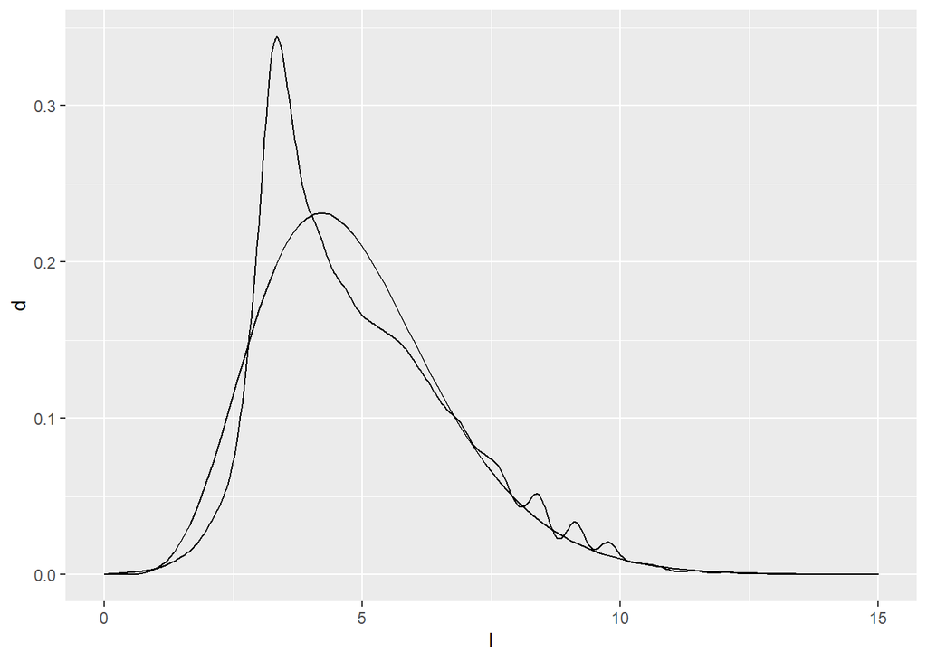

```r
gammdf <- tibble(
  l = seq(0, 30, length.out=200),
  d = dgamma(l, shape = alphamom, scale = 1/betamom)
)
ggplot(whitingDF, aes(x = l), adjust = 1.5) +
  geom_density() +
  geom_line(data = gammdf, aes(l, d)) +
  xlim(0,15)
```

The error with these parameters is

```r
momerr = gammaErrorSq(alphamom, 1/betamom)
momerr$value
```

```
## [1] 0.0129488
```

This is actually better than any of the values in the matrix so we can consider this to be a good estimate.